# Exercise 6b: ANOVA

2023-02-22

## Example 1: Comparing bill length across species of penguins

We would like to know if the mean bill length varies between species of penguins included in the `palmerpenguins` dataset. We know the dataset pretty well at this point, so let’s go ahead and load it:

```r
penguins <- penguins
```

#### Q1.1. Start by visualizing the distribution of bill length across the groups using a boxplot. Remember to think about what your continuous variable is and what your grouping variable is.

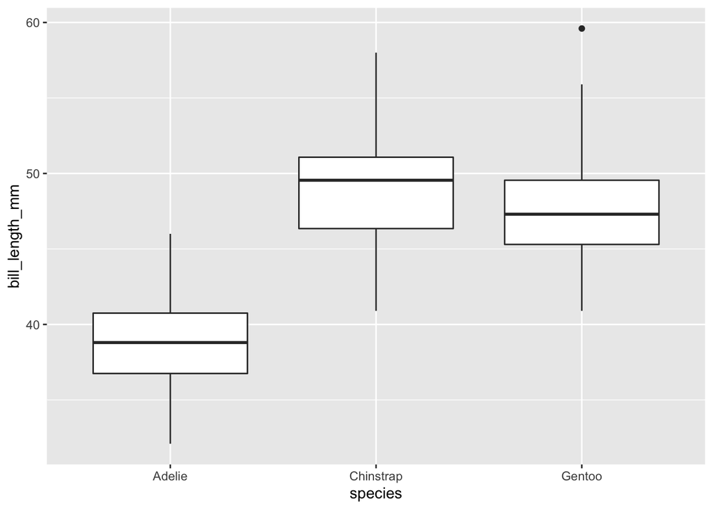

```r
ggplot(data = penguins, aes(x = species, y = bill_length_mm))+
  geom_boxplot()
```

#### Q1.2. From the boxplots above, do you think it’s likely that the groups differ in mean bill length? And if so, which group(s) do you think are different?

Yes, the groups differ. Adelie penguins look like they have smaller bill lenghts than either of the two other groups

#### Q1.3. Given the number of groups and the type of variable you’d like to compare across them, which type of test should you use?

ANOVA

### Q1.4. Let’s start off by stating our null and alternate hypothesis.

H<sub>0</sub>: The mean bill length is the same across species H<sub>1</sub>: The mean bill length is not the same across species

#### Q1.5. What are the assumptions for this test?

1. Independence of assumptions
2. Normality
3. Homogeneity of variance

#### Q1.6. Test the normality assumption

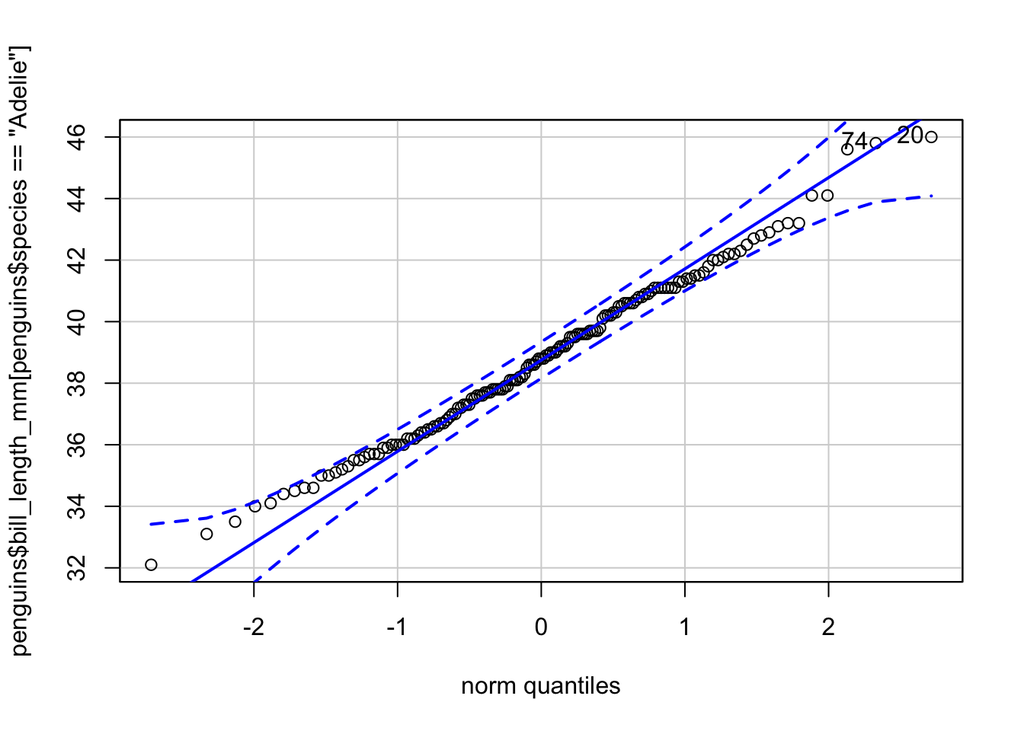

```
## [1] 20 74
```

```r
qqPlot(penguins$bill_length_mm[penguins$species == "Adelie"])
```

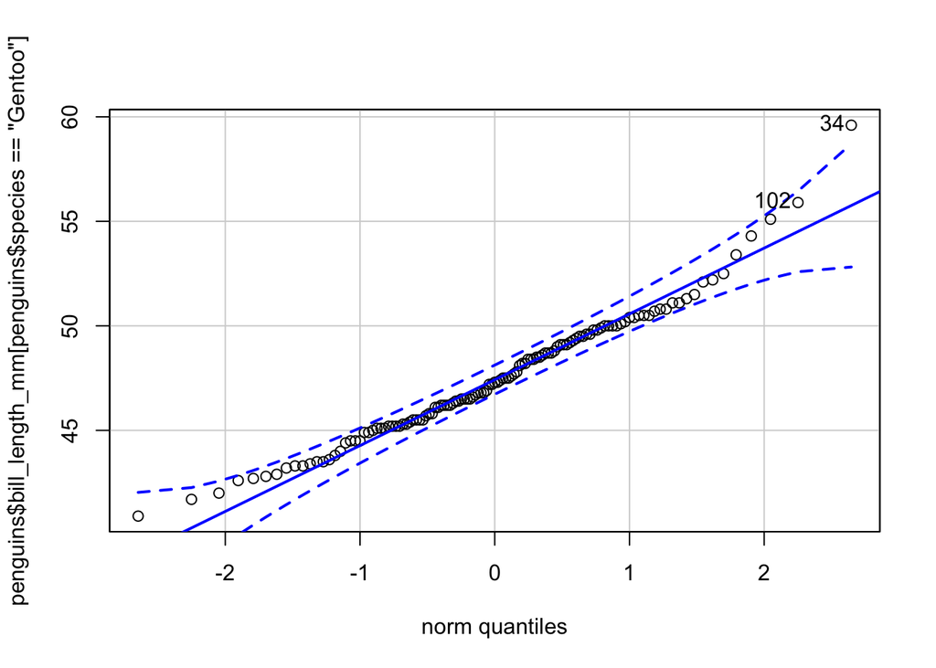

```
## [1]  34 102
```

```r
qqPlot(penguins$bill_length_mm[penguins$species == "Gentoo"])
```

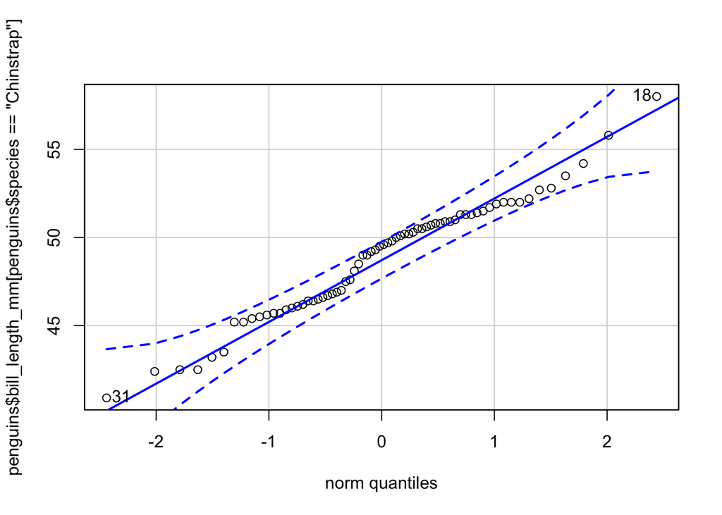

```
## [1] 18 31
```

```r
qqPlot(penguins$bill_length_mm[penguins$species == "Chinstrap"])
```

```r
shapiro.test(penguins$bill_length_mm[penguins$species == "Adelie"])
```

```
##
##  Shapiro-Wilk normality test
##
## data:  penguins$bill_length_mm[penguins$species == "Adelie"]
## W = 0.99336, p-value = 0.7166
```

```r
shapiro.test(penguins$bill_length_mm[penguins$species == "Gentoo"])
```

```
##
##  Shapiro-Wilk normality test
##
## data:  penguins$bill_length_mm[penguins$species == "Gentoo"]
## W = 0.97272, p-value = 0.01349
```

```r
shapiro.test(penguins$bill_length_mm[penguins$species == "Chinstrap"])
```

```
##
##  Shapiro-Wilk normality test
##
## data:  penguins$bill_length_mm[penguins$species == "Chinstrap"]
## W = 0.97525, p-value = 0.1941
```

#### Q1.7. Test the homogeneity of variance assumption

```r
leveneTest(bill_length_mm ~ species,  data = penguins)
```

```
## Levene's Test for Homogeneity of Variance (center = median)
##        Df F value Pr(>F)
## group   2  2.2425 0.1078
##       339
```

#### Q1.8. You’ve now got an example where a single individual has thrown off your Shapiro test. Consider that the Gentoo species has met normality. Other than that test, have the assumptions for the ANOVA analysis been met?

Yes

#### Q1.9. Perform the ANOVA analysis

```r
anova1 <- aov(bill_length_mm ~ species,  data = penguins)
summary(anova1)
```

```
##              Df Sum Sq Mean Sq F value Pr(>F)
## species       2   7194    3597   410.6 <2e-16 ***
## Residuals   339   2970       9
## ---
## Signif. codes:  0 '***' 0.001 '**' 0.01 '*' 0.05 '.' 0.1 ' ' 1
## 2 observations deleted due to missingness
```

#### Q1.10. Consider the results from your ANOVA test. What do you conclude about your null hypothesis?

We reject the null hypothesis

#### Q1.11. Perform your post-hoc test. Between which groups does there seem to be a difference?

```r
TukeyHSD(anova1)
```

```
##   Tukey multiple comparisons of means
##     95% family-wise confidence level
##
## Fit: aov(formula = bill_length_mm ~ species, data = penguins)
##
## $species
##                       diff       lwr        upr     p adj
## Chinstrap-Adelie 10.042433  9.024859 11.0600064 0.0000000
## Gentoo-Adelie     8.713487  7.867194  9.5597807 0.0000000
## Gentoo-Chinstrap -1.328945 -2.381868 -0.2760231 0.0088993
```

## Example 2: Displacement in engines with different numbers of gears

We’re interested in knowing whether engines with different gears have different displacement - that is, the volume moved by an engine. The data is contained in the `mtcars` data which is loaded with `dplyr`

```r
mtcars <- mtcars

mtcars <- mtcars %>%
  mutate(gear = as.factor(gear))
```

#### Q2.1. Start by visualizing the distribution of `disp` across the groups using a boxplot. Remember to think about what your continuous variable is and what your grouping variable is.

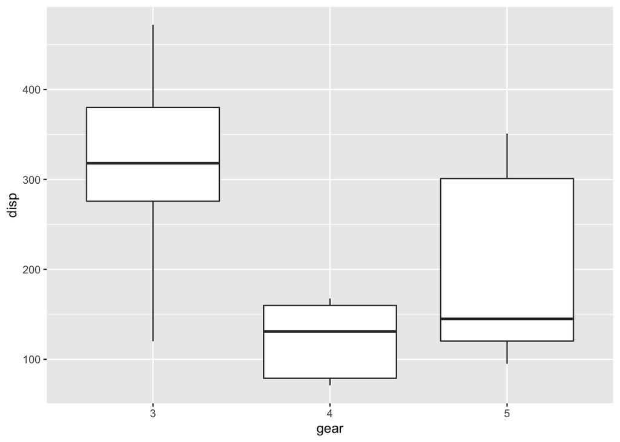

```r
ggplot(data = mtcars, aes(x = gear, y = disp))+
  geom_boxplot()
```

#### Q2.2. From the boxplots above, do you think it’s likely that the groups differ in displacement? And if so, which group(s) do you think are different?

Yes, the groups differ. Cars with 3 gears may have higher displacement.

#### Q2.3. Given the number of groups and the type of variable you’d like to compare across them, which type of test should you use?

ANOVA

### Q2.4. Let’s start off by stating our null and alternate hypothesis.

H<sub>0</sub>: The mean displacement is the same across cars with different numbers of gears H<sub>1</sub>: The mean displacement is not the same across cars with different numbers of gears

#### Q2.5. What are the assumptions for this test?

1. Independence of assumptions
2. Normality
3. Homogeneity of variance

#### Q2.6. Test the normality assumption

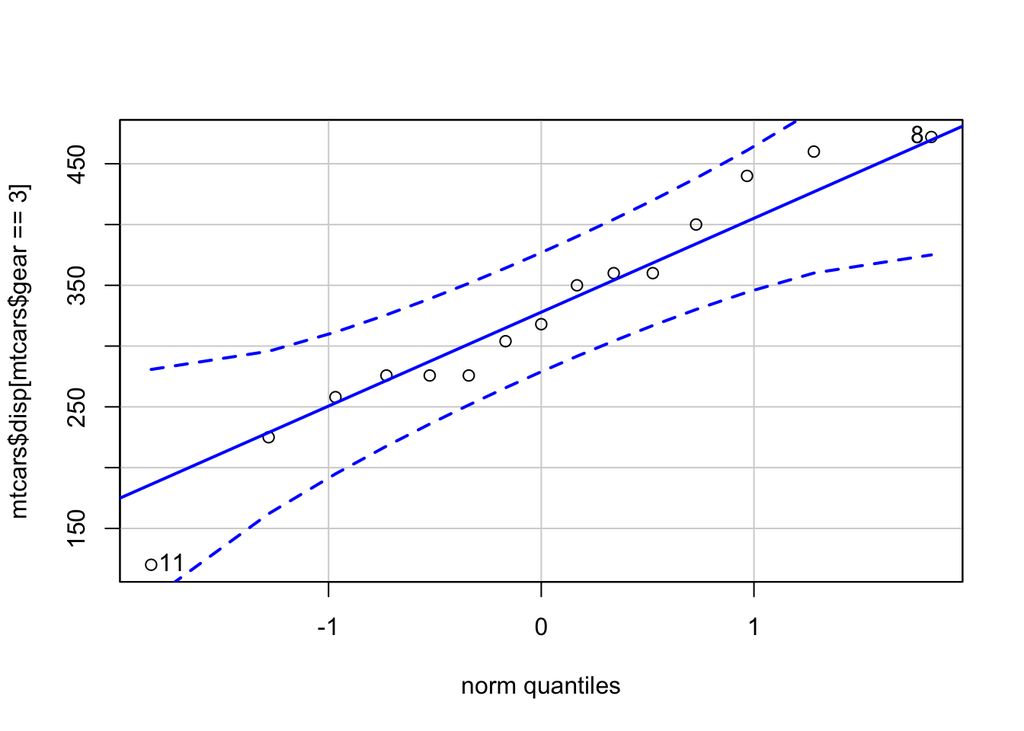

```
## [1] 11  8
```

```r
qqPlot(mtcars$disp[mtcars$gear == 3])
```

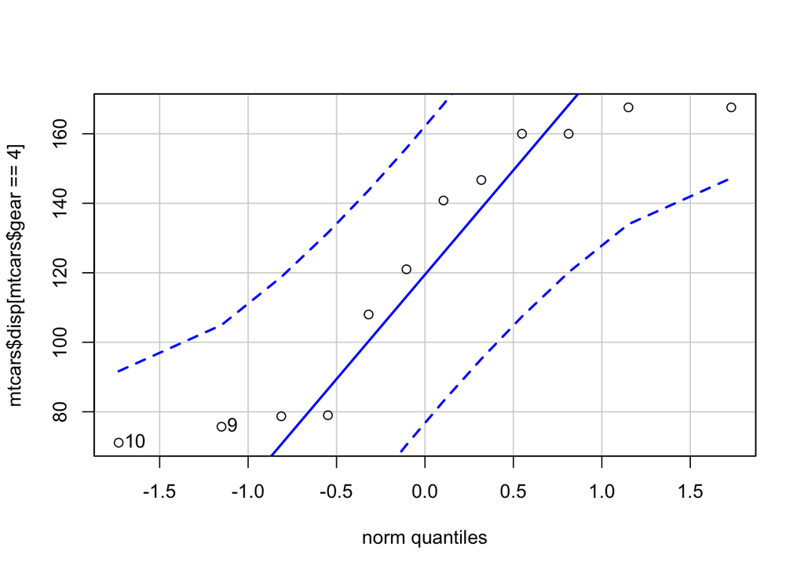

```
## [1] 10  9
```

```r
qqPlot(mtcars$disp[mtcars$gear == 4])
```

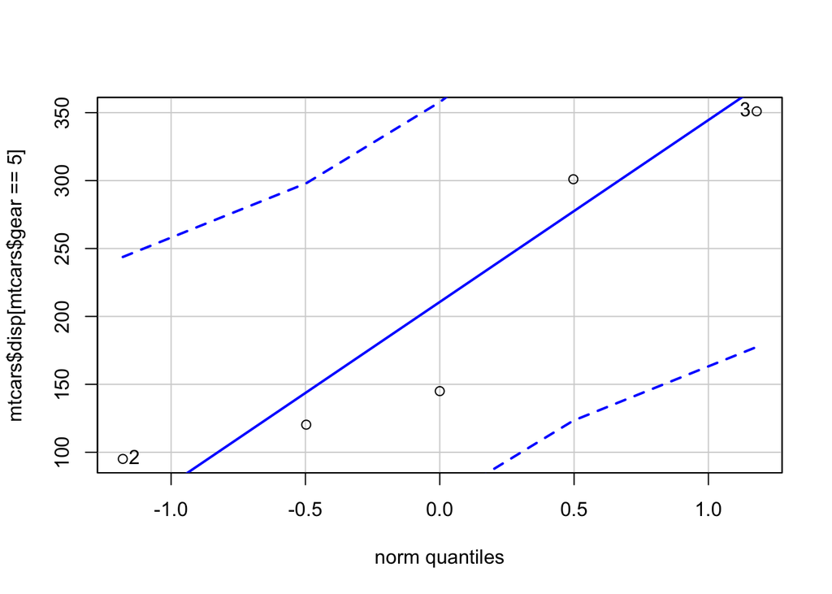

```
## [1] 3 2
```

```r
qqPlot(mtcars$disp[mtcars$gear == 5])
```

```r
shapiro.test(mtcars$disp[mtcars$gear == 3])
```

```
##
##  Shapiro-Wilk normality test
##
## data:  mtcars$disp[mtcars$gear == 3]
## W = 0.964, p-value = 0.7614
```

```r
shapiro.test(mtcars$disp[mtcars$gear == 4])
```

```
##
##  Shapiro-Wilk normality test
##
## data:  mtcars$disp[mtcars$gear == 4]
## W = 0.85757, p-value = 0.04559
```

```r
shapiro.test(mtcars$disp[mtcars$gear == 5])
```

```
##
##  Shapiro-Wilk normality test
##
## data:  mtcars$disp[mtcars$gear == 5]
## W = 0.85592, p-value = 0.214
```

#### Q2.7. Test the homogeneity of variance assumption

```r
leveneTest(disp ~ factor(gear),  data = mtcars)
```

```
## Levene's Test for Homogeneity of Variance (center = median)
##       Df F value  Pr(>F)
## group  2  2.6357 0.08877 .
##       29
## ---
## Signif. codes:  0 '***' 0.001 '**' 0.01 '*' 0.05 '.' 0.1 ' ' 1
```

#### Q2.8. You’ve now got an example where the p-value for normality is marginal. Consider that the 4-gear group has met normality. Other than that test, have the assumptions for the ANOVA analysis been met?

Yes

#### Q1.9. Perform the ANOVA analysis

```r
anova2 <- aov(disp ~ factor(gear),  data = mtcars)
summary(anova2)
```

```
##              Df Sum Sq Mean Sq F value   Pr(>F)
## factor(gear)  2 280221  140110   20.73 2.56e-06 ***
## Residuals    29 195964    6757
## ---
## Signif. codes:  0 '***' 0.001 '**' 0.01 '*' 0.05 '.' 0.1 ' ' 1
```

#### Q1.10. Consider the results from your ANOVA test. What do you conclude about your null hypothesis?

We reject the null hypothesis

#### Q1.11. Perform your post-hoc test. Between which groups does there seem to be a difference?

It looks like group 3 is different, and has greater displacement than either group 4 or group 5

```r
TukeyHSD(anova2)
```

```
##   Tukey multiple comparisons of means
##     95% family-wise confidence level
##
## Fit: aov(formula = disp ~ factor(gear), data = mtcars)
##
## $`factor(gear)`
##           diff       lwr        upr     p adj
## 4-3 -203.28333 -281.9100 -124.65666 0.0000016
## 5-3 -123.82000 -228.6556  -18.98443 0.0180037
## 5-4   79.46333  -28.5987  187.52536 0.1821800
```